# Homework 2

Author

Faith Okaalo

Published

February 18, 2026

## Homework 2: Data Visualization and Wrangling.

### Step 1: Data wrangling

Load required libraries

```r
library(data.table)
library(dplyr)
library(tidyr)
library(leaflet)
library(knitr)
library(tidyverse)
library(DescTools)
library(janitor)
library(skimr)
library(ggplot2)
library(gridExtra)
library(leaflet)
```

Read in the two datasets

```r
individual <- read.csv("C:/Users/faith/Downloads/chs_individual.csv")
regional <- read.csv("C:/Users/faith/Downloads/chs_regional.csv")
```

Looking at both datasets

```r
print(head(individual))
```

```
  sid  townname male race hispanic    agepft height weight      bmi asthma
1   1 Lancaster    1    W        0 10.154689    123     54 16.22411      0
2   2 Lancaster    1    W        0 10.461328    145     77 16.64685      0
3   6 Lancaster    0    B        0 10.097194    145    143 30.91558      0
4   7 Lancaster    0    O        0 10.746064    156     72 13.44809      0
5   8 Lancaster    0    W        1  9.782341    132     61 15.91326      0
6  10 Lancaster    1    O        1        NA     NA     NA       NA      0
  active_asthma father_asthma mother_asthma wheeze hayfever allergy educ_parent
1             0             0             0      0        0       0           3
2             0             0             0      1        0       0           5
3             0             0             0      0        1       0           2
4             0            NA             0      1        0       0           2
5             0             1             0      1        1       1           3
6             1             1             0      0        0       0           1
  smoke pets gasstove      fev      fvc     mmef
1     0    1        1 1650.254 1800.005 2537.777
2     0    1        0 2273.129 2721.111 2365.745
3     0    0        1 2011.653 2257.244 1818.973
4     1    1        1 1643.092 2060.526 1462.500
5     0    1        0 1651.974 1996.382 1606.579
6     0    1        1       NA       NA       NA
```

```r
print(head(regional))
```

```
       townname pm25_mass pm25_so4 pm25_no3 pm25_nh4 pm25_oc pm25_ec pm25_om
1        Alpine      8.74     1.73     1.59     0.88    2.54    0.48    3.04
2 Lake Elsinore     12.35     1.90     2.98     1.36    3.64    0.62    4.36
3  Lake Gregory      7.66     1.07     2.07     0.91    2.46    0.40    2.96
4     Lancaster      8.50     0.91     1.87     0.78    4.43    0.55    5.32
5        Lompoc      5.96     1.08     0.73     0.41    1.45    0.13    1.74
6    Long Beach     19.12     3.23     6.22     2.57    5.21    1.36    6.25
  pm10_oc pm10_ec pm10_tc formic acetic  hcl hno3 o3_max o3106 o3_24   no2
1    3.25    0.49    3.75   1.03   2.49 0.41 1.98  65.82 55.05 41.23 12.18
2    4.66    0.63    5.29   1.18   3.56 0.46 2.63  66.70 54.42 32.23 17.03
3    3.16    0.41    3.57   0.66   2.36 0.28 2.28  84.44 67.01 57.76  7.62
4    5.68    0.56    8.61   0.88   2.88 0.22 1.80  54.81 43.88 32.86 15.77
5    1.86    0.14    1.99   0.34   0.75 0.33 0.43  43.85 37.74 28.37  4.60
6    6.68    1.39    8.07   1.57   2.94 0.73 2.67  39.44 28.22 18.22 33.11
   pm10 no_24hr pm2_5_fr iacid oacid total_acids       lon      lat
1 24.73    2.48    10.28  2.39  3.52        5.50 -116.7664 32.83505
2 34.25    7.07    14.53  3.09  4.74        7.37 -117.3273 33.66808
3 20.05      NA     9.01  2.56  3.02        5.30 -117.2752 34.24290
4 25.04   12.68       NA  2.02  3.76        5.56 -118.1542 34.68678
5 18.40    2.05       NA  0.76  1.09        1.52 -120.4579 34.63915
6 38.41   36.76    22.23  3.40  4.51        7.18 -118.1937 33.77005
```

**Merge the two datasets**

```r
shared_vars <- intersect(names(individual), names(regional))
shared_vars
```

```
[1] "townname"
```

Rename townname to location in both datasets

```r
individual <- individual %>% rename(location = townname)
regional <- regional %>% rename(location = townname)

cat("Key column in individual data:", "location" %in% names(individual), "\n")
```

```
Key column in individual data: TRUE
```

```r
cat("Key column in regional data:  ", "location" %in% names(regional), "\n")
```

```
Key column in regional data:   TRUE
```

Merge the two datasets

```r
chs <- left_join(individual, regional, by = "location")
```

Confirm row count.

```r
cat("Rows before merge (individual):", nrow(individual), "\n")
```

```
Rows before merge (individual): 1200
```

```r
cat("Rows after merge:              ", nrow(chs), "\n")
```

```
Rows after merge:               1200
```

```r
print(head(chs[, c("location", "male", "hispanic", "bmi", "fev", "pm25_mass")]))
```

```
   location male hispanic      bmi      fev pm25_mass
1 Lancaster    1        0 16.22411 1650.254       8.5
2 Lancaster    1        0 16.64685 2273.129       8.5
3 Lancaster    0        0 30.91558 2011.653       8.5
4 Lancaster    0        0 13.44809 1643.092       8.5
5 Lancaster    0        1 15.91326 1651.974       8.5
6 Lancaster    1        1       NA       NA       8.5
```

```r
n_dupes <- sum(duplicated(chs))
cat("Number of duplicate rows:", n_dupes, "\n")
```

```
Number of duplicate rows: 0
```

The merged data has 1200 rows which is similar to the originial individual dataset. No duplicates were introduced.

**Check missing values**

Per columns

```r
na_counts <- colSums(is.na(chs))
na_counts[na_counts > 0]
```

```
       agepft        height        weight           bmi        asthma
           89            89            89            89            31
father_asthma mother_asthma        wheeze      hayfever       allergy
          106            56            71           118            63
  educ_parent         smoke      gasstove           fev           fvc
           64            40            33            95            97
         mmef       no_24hr      pm2_5_fr
          106           100           300
```

Proportion of NAs per column as a percentage

```r
na_pct <- round(colMeans(is.na(chs)) * 100, 2)
cat("\nProportion missing per column (%):\n")
```

```
Proportion missing per column (%):
```

```r
print(na_pct[na_pct > 0])
```

```
       agepft        height        weight           bmi        asthma
         7.42          7.42          7.42          7.42          2.58
father_asthma mother_asthma        wheeze      hayfever       allergy
         8.83          4.67          5.92          9.83          5.25
  educ_parent         smoke      gasstove           fev           fvc
         5.33          3.33          2.75          7.92          8.08
         mmef       no_24hr      pm2_5_fr
         8.83          8.33         25.00
```

Per row

```r
cat("\nRows with at least one NA:", sum(!complete.cases(chs)), "out of", nrow(chs), "\n")
```

```
Rows with at least one NA: 681 out of 1200
```

Total NA cells

```r
cat("Total NA cells:", sum(is.na(chs)), "\n")
```

```
Total NA cells: 1636
```

```r
skim(chs)
```

Data summary

| Name | chs |
| --- | --- |
| Number of rows | 1200 |
| Number of columns | 49 |
| _______________________ |  |
| Column type frequency: |  |
| character | 2 |
| numeric | 47 |
| ________________________ |  |
| Group variables | None |

**Variable type: character**

| skim_variable | n_missing | complete_rate | min | max | empty | n_unique | whitespace |
| --- | --- | --- | --- | --- | --- | --- | --- |
| location | 0 | 1 | 6 | 13 | 0 | 12 | 0 |
| race | 0 | 1 | 1 | 1 | 0 | 6 | 0 |

**Variable type: numeric**

| skim_variable | n_missing | complete_rate | mean | sd | p0 | p25 | p50 | p75 | p100 | hist |
| --- | --- | --- | --- | --- | --- | --- | --- | --- | --- | --- |
| sid | 0 | 1.00 | 1037.52 | 592.75 | 1.00 | 528.75 | 1041.50 | 1554.25 | 2053.00 | ▇▇▇▇▇ |
| male | 0 | 1.00 | 0.49 | 0.50 | 0.00 | 0.00 | 0.00 | 1.00 | 1.00 | ▇▁▁▁▇ |
| hispanic | 0 | 1.00 | 0.43 | 0.50 | 0.00 | 0.00 | 0.00 | 1.00 | 1.00 | ▇▁▁▁▆ |
| agepft | 89 | 0.93 | 9.92 | 0.43 | 8.96 | 9.61 | 9.91 | 10.18 | 12.73 | ▅▇▁▁▁ |
| height | 89 | 0.93 | 138.96 | 6.74 | 114.00 | 135.00 | 139.00 | 143.00 | 165.00 | ▁▃▇▂▁ |
| weight | 89 | 0.93 | 79.33 | 20.68 | 42.00 | 65.00 | 74.00 | 89.00 | 207.00 | ▇▆▁▁▁ |
| bmi | 89 | 0.93 | 18.50 | 3.78 | 11.30 | 15.78 | 17.48 | 20.35 | 41.27 | ▇▇▂▁▁ |
| asthma | 31 | 0.97 | 0.15 | 0.35 | 0.00 | 0.00 | 0.00 | 0.00 | 1.00 | ▇▁▁▁▂ |
| active_asthma | 0 | 1.00 | 0.19 | 0.39 | 0.00 | 0.00 | 0.00 | 0.00 | 1.00 | ▇▁▁▁▂ |
| father_asthma | 106 | 0.91 | 0.08 | 0.28 | 0.00 | 0.00 | 0.00 | 0.00 | 1.00 | ▇▁▁▁▁ |
| mother_asthma | 56 | 0.95 | 0.10 | 0.30 | 0.00 | 0.00 | 0.00 | 0.00 | 1.00 | ▇▁▁▁▁ |
| wheeze | 71 | 0.94 | 0.33 | 0.47 | 0.00 | 0.00 | 0.00 | 1.00 | 1.00 | ▇▁▁▁▃ |
| hayfever | 118 | 0.90 | 0.17 | 0.38 | 0.00 | 0.00 | 0.00 | 0.00 | 1.00 | ▇▁▁▁▂ |
| allergy | 63 | 0.95 | 0.29 | 0.46 | 0.00 | 0.00 | 0.00 | 1.00 | 1.00 | ▇▁▁▁▃ |
| educ_parent | 64 | 0.95 | 2.80 | 1.11 | 1.00 | 2.00 | 3.00 | 3.00 | 5.00 | ▂▃▇▂▂ |
| smoke | 40 | 0.97 | 0.16 | 0.37 | 0.00 | 0.00 | 0.00 | 0.00 | 1.00 | ▇▁▁▁▂ |
| pets | 0 | 1.00 | 0.77 | 0.42 | 0.00 | 1.00 | 1.00 | 1.00 | 1.00 | ▂▁▁▁▇ |
| gasstove | 33 | 0.97 | 0.78 | 0.41 | 0.00 | 1.00 | 1.00 | 1.00 | 1.00 | ▂▁▁▁▇ |
| fev | 95 | 0.92 | 2031.27 | 330.67 | 984.85 | 1808.97 | 2022.74 | 2249.72 | 3323.68 | ▁▆▇▂▁ |
| fvc | 97 | 0.92 | 2323.92 | 397.36 | 894.97 | 2041.08 | 2293.42 | 2572.78 | 3698.33 | ▁▃▇▃▁ |
| mmef | 106 | 0.91 | 2398.77 | 588.48 | 757.58 | 1993.95 | 2401.52 | 2793.81 | 4935.91 | ▂▇▇▁▁ |
| pm25_mass | 0 | 1.00 | 14.36 | 7.74 | 5.96 | 7.62 | 10.54 | 20.99 | 29.97 | ▇▁▁▃▁ |
| pm25_so4 | 0 | 1.00 | 1.88 | 0.79 | 0.79 | 1.08 | 1.81 | 2.60 | 3.23 | ▇▃▂▇▂ |
| pm25_no3 | 0 | 1.00 | 4.49 | 3.60 | 0.73 | 1.54 | 2.52 | 7.34 | 12.20 | ▇▁▂▂▁ |
| pm25_nh4 | 0 | 1.00 | 1.76 | 1.23 | 0.41 | 0.74 | 1.14 | 2.77 | 4.25 | ▇▁▂▂▁ |
| pm25_oc | 0 | 1.00 | 4.55 | 2.64 | 1.45 | 2.52 | 4.04 | 5.35 | 11.83 | ▇▇▂▁▂ |
| pm25_ec | 0 | 1.00 | 0.74 | 0.40 | 0.13 | 0.40 | 0.58 | 1.17 | 1.36 | ▃▇▁▂▆ |
| pm25_om | 0 | 1.00 | 5.46 | 3.18 | 1.74 | 3.02 | 4.84 | 6.42 | 14.20 | ▇▇▂▁▂ |
| pm10_oc | 0 | 1.00 | 5.83 | 3.39 | 1.86 | 3.23 | 5.17 | 6.86 | 15.16 | ▇▇▂▁▂ |
| pm10_ec | 0 | 1.00 | 0.75 | 0.41 | 0.14 | 0.41 | 0.60 | 1.20 | 1.39 | ▃▇▁▂▆ |
| pm10_tc | 0 | 1.00 | 6.78 | 3.76 | 1.99 | 3.70 | 6.50 | 8.43 | 16.44 | ▇▃▆▁▂ |
| formic | 0 | 1.00 | 1.33 | 0.77 | 0.34 | 0.72 | 1.10 | 1.77 | 2.77 | ▇▆▃▂▃ |
| acetic | 0 | 1.00 | 3.01 | 1.32 | 0.75 | 2.30 | 2.91 | 4.00 | 5.14 | ▅▇▅▇▅ |
| hcl | 0 | 1.00 | 0.42 | 0.13 | 0.22 | 0.32 | 0.44 | 0.46 | 0.73 | ▆▆▇▂▂ |
| hno3 | 0 | 1.00 | 2.37 | 1.18 | 0.43 | 1.59 | 2.46 | 3.36 | 4.07 | ▇▂▅▇▇ |
| o3_max | 0 | 1.00 | 60.16 | 14.12 | 38.27 | 49.93 | 64.04 | 67.69 | 84.44 | ▇▅▇▅▅ |
| o3106 | 0 | 1.00 | 47.76 | 11.18 | 28.22 | 41.90 | 46.75 | 55.24 | 67.01 | ▅▅▇▇▅ |
| o3_24 | 0 | 1.00 | 30.22 | 10.20 | 18.22 | 23.31 | 27.59 | 32.39 | 57.76 | ▅▇▁▁▁ |
| no2 | 0 | 1.00 | 18.99 | 10.49 | 4.60 | 12.12 | 16.40 | 23.24 | 37.97 | ▃▇▃▁▅ |
| pm10 | 0 | 1.00 | 32.64 | 14.33 | 18.40 | 20.71 | 29.64 | 39.16 | 70.39 | ▇▃▂▁▁ |
| no_24hr | 100 | 0.92 | 16.21 | 13.25 | 2.05 | 4.74 | 12.68 | 26.90 | 42.95 | ▇▃▂▂▃ |
| pm2_5_fr | 300 | 0.75 | 19.79 | 8.48 | 9.01 | 10.28 | 22.23 | 27.73 | 31.55 | ▇▂▂▂▇ |
| iacid | 0 | 1.00 | 2.79 | 1.25 | 0.76 | 1.84 | 2.83 | 3.82 | 4.62 | ▇▂▅▇▇ |
| oacid | 0 | 1.00 | 4.34 | 2.02 | 1.09 | 2.98 | 4.14 | 5.98 | 7.40 | ▅▇▇▂▇ |
| total_acids | 0 | 1.00 | 6.71 | 3.17 | 1.52 | 4.93 | 6.37 | 9.39 | 11.43 | ▃▃▇▂▆ |
| lon | 0 | 1.00 | -118.30 | 1.33 | -120.67 | -118.75 | -117.73 | -117.36 | -116.77 | ▅▁▁▆▇ |
| lat | 0 | 1.00 | 34.20 | 0.65 | 32.84 | 33.93 | 34.10 | 34.65 | 35.49 | ▂▃▇▅▂ |

**Impute**

```r
# Continuous variables: impute with GROUP MEAN (male x hispanic)
cont_vars <- c("agepft", "height", "weight", "bmi", "fev", "fvc", "mmef",
               "pm25_mass", "pm25_so4", "pm25_no3", "pm25_nh4", "pm25_oc",
               "pm25_ec", "pm25_om", "pm10_oc", "pm10_ec", "pm10_tc",
               "formic", "acetic", "hcl", "hno3", "o3_max", "o3106",
               "o3_24", "no2", "pm10", "no_24hr", "pm2_5_fr",
               "iacid", "oacid", "total_acids")
```

```r
# Categorical/binary variables: impute with GROUP MODE (male x hispanic)
cat_vars <- c("asthma", "active_asthma", "father_asthma", "mother_asthma",
              "wheeze", "hayfever", "allergy", "educ_parent",
              "smoke", "pets", "gasstove")
```

Check NAs before imputation

```r
cat("=== BEFORE IMPUTATION ===\n")
```

```
=== BEFORE IMPUTATION ===
```

```r
cat("NAs in continuous variables:\n")
```

```
NAs in continuous variables:
```

```r
print(colSums(is.na(chs[, cont_vars])))
```

```
     agepft      height      weight         bmi         fev         fvc
         89          89          89          89          95          97
       mmef   pm25_mass    pm25_so4    pm25_no3    pm25_nh4     pm25_oc
        106           0           0           0           0           0
    pm25_ec     pm25_om     pm10_oc     pm10_ec     pm10_tc      formic
          0           0           0           0           0           0
     acetic         hcl        hno3      o3_max       o3106       o3_24
          0           0           0           0           0           0
        no2        pm10     no_24hr    pm2_5_fr       iacid       oacid
          0           0         100         300           0           0
total_acids
          0
```

```r
cat("\nNAs in categorical variables:\n")
```

```
NAs in categorical variables:
```

```r
print(colSums(is.na(chs[, cat_vars])))
```

```
       asthma active_asthma father_asthma mother_asthma        wheeze
           31             0           106            56            71
     hayfever       allergy   educ_parent         smoke          pets
          118            63            64            40             0
     gasstove
           33
```

```r
cat("\nTotal rows with at least one NA:", sum(!complete.cases(chs)), "\n")
```

```
Total rows with at least one NA: 681
```

**Impute continous variables with group means**

```r
chs <- chs %>%
  group_by(male, hispanic) %>%
  mutate(across(all_of(cont_vars),
                ~ ifelse(is.na(.), mean(., na.rm = TRUE), .))) %>%
  ungroup()
```

**Impute categorical variables with mode**

```r
chs <- chs %>%
  group_by(male, hispanic) %>%
  mutate(across(all_of(cat_vars),
                ~ ifelse(is.na(.), Mode(., na.rm = TRUE)[1], .))) %>%
  ungroup()
```

**Check NAs after imputation**

```r
cat("\n=== AFTER IMPUTATION ===\n")
```

```
=== AFTER IMPUTATION ===
```

```r
cat("NAs in continuous variables:\n")
```

```
NAs in continuous variables:
```

```r
print(colSums(is.na(chs[, cont_vars])))
```

```
     agepft      height      weight         bmi         fev         fvc
          0           0           0           0           0           0
       mmef   pm25_mass    pm25_so4    pm25_no3    pm25_nh4     pm25_oc
          0           0           0           0           0           0
    pm25_ec     pm25_om     pm10_oc     pm10_ec     pm10_tc      formic
          0           0           0           0           0           0
     acetic         hcl        hno3      o3_max       o3106       o3_24
          0           0           0           0           0           0
        no2        pm10     no_24hr    pm2_5_fr       iacid       oacid
          0           0           0           0           0           0
total_acids
          0
```

```r
cat("\nNAs in categorical variables:\n")
```

```
NAs in categorical variables:
```

```r
print(colSums(is.na(chs[, cat_vars])))
```

```
       asthma active_asthma father_asthma mother_asthma        wheeze
            0             0             0             0             0
     hayfever       allergy   educ_parent         smoke          pets
            0             0             0             0             0
     gasstove
            0
```

```r
cat("\nTotal rows with at least one NA:", sum(!complete.cases(chs)), "\n")
```

```
Total rows with at least one NA: 0
```

```r
cat("Total NA cells remaining:", sum(is.na(chs)), "\n")
```

```
Total NA cells remaining: 0
```

```r
print(head(chs[, c("location", "male", "hispanic", "bmi", "fev", "smoke", "gasstove")]))
```

```
# A tibble: 6 × 7
  location   male hispanic   bmi   fev smoke gasstove
  <chr>     <int>    <int> <dbl> <dbl> <int>    <int>
1 Lancaster     1        0  16.2 1650.     0        1
2 Lancaster     1        0  16.6 2273.     0        0
3 Lancaster     0        0  30.9 2012.     0        1
4 Lancaster     0        0  13.4 1643.     1        1
5 Lancaster     0        1  15.9 1652.     0        0
6 Lancaster     1        1  19.4 2120.     0        1
```

### Step 2: Create a categorical variable called “obesity-level”

```r
chs <- chs %>%
  mutate(obesity_level = case_when(
    bmi < 14            ~ "Underweight",
    bmi >= 14 & bmi <= 22 ~ "Normal",
    bmi > 22 & bmi <= 24  ~ "Overweight",
    bmi > 24            ~ "Obese"
  ))


# Set the order
chs$obesity_level <- factor(chs$obesity_level,
                             levels = c("Underweight", "Normal", "Overweight", "Obese"))
```

**A summary table for the obesity-level variable**

```r
# Minimun BMI, maximum BMI and counts per categor
obesity_summary <- chs %>%
  group_by(obesity_level) %>%
  summarise(Min_BMI   = round(min(bmi, na.rm = TRUE), 2),
    Max_BMI   = round(max(bmi, na.rm = TRUE), 2),
    N         = n())

kable(obesity_summary, caption = "Summary of the Obesity Level variable")
```

Summary of the Obesity Level variable

| obesity_level | Min_BMI | Max_BMI | N |
| --- | --- | --- | --- |
| Underweight | 11.30 | 13.99 | 35 |
| Normal | 14.00 | 21.96 | 975 |
| Overweight | 22.02 | 24.00 | 87 |
| Obese | 24.01 | 41.27 | 103 |

The summary table confirms that the BMI cutoffs are correctly applied, and the minimum and maximum BMIs within each category fall within the expected ranges.

### Step 3: Create a categorical variable called “smoke_gas_exposure”

Combine smoke and gasstove into one variable with 4 categories

```r
chs <- chs %>%
  mutate(smoke_gas_exposure = case_when(
    smoke == 0 & gasstove == 0 ~ "No Smoke, No Gas",
    smoke == 1 & gasstove == 0 ~ "Smoke Only",
    smoke == 0 & gasstove == 1 ~ "Gas Only",
    smoke == 1 & gasstove == 1 ~ "Smoke and Gas"
  ))

chs$smoke_gas_exposure <- factor(chs$smoke_gas_exposure,
                                  levels = c("No Smoke, No Gas", "Smoke Only",
                                             "Gas Only", "Smoke and Gas"))
```

```r
#Counts per category
print(table(chs$smoke_gas_exposure))
```

```
No Smoke, No Gas       Smoke Only         Gas Only    Smoke and Gas
             219               36              791              154
```

### Step 4: Summary tables of FEV

FEV by location

```r
fev_town <- chs %>%
  group_by(location) %>%
  summarise(
    Mean_FEV = round(mean(fev, na.rm = TRUE), 2),
    SD_FEV   = round(sd(fev, na.rm = TRUE), 2),
    N        = n()
  ) %>% arrange(desc(Mean_FEV))

kable(fev_town, caption = "Average FEV by Town")
```

Average FEV by Town

| location | Mean_FEV | SD_FEV | N |
| --- | --- | --- | --- |
| Alpine | 2087.10 | 291.18 | 100 |
| Lake Gregory | 2084.70 | 319.96 | 100 |
| Atascadero | 2075.90 | 324.09 | 100 |
| Lake Elsinore | 2038.85 | 303.70 | 100 |
| Lompoc | 2034.35 | 351.05 | 100 |
| San Dimas | 2026.79 | 318.78 | 100 |
| Santa Maria | 2025.75 | 312.17 | 100 |
| Upland | 2024.27 | 343.16 | 100 |
| Lancaster | 2003.04 | 317.13 | 100 |
| Riverside | 1989.88 | 277.51 | 100 |
| Long Beach | 1985.86 | 319.46 | 100 |
| Mira Loma | 1985.20 | 324.96 | 100 |

The average FEV varied across the towns, ranging from 1985.20 ml in Mira Loma to 2087.10 in Alpine, with a difference of approximately 102 ml. The difference between the highest and lowest towns is modest relative to the within-town variability, which is approximately 300 ml across most towns.

**FEV by sex**

```r
fev_sex <- chs %>%
  mutate(Sex = ifelse(male == 1, "Male", "Female")) %>%
  group_by(Sex) %>%
  summarise(
    Proportion_Male = round(mean(male, na.rm = TRUE), 2),
    Mean_FEV = round(mean(fev, na.rm = TRUE), 2),
    SD_FEV   = round(sd(fev, na.rm = TRUE), 2),
    N        = n()
  )

kable(fev_sex, caption = "Average FEV by Sex")
```

Average FEV by Sex

| Sex | Proportion_Male | Mean_FEV | SD_FEV | N |
| --- | --- | --- | --- | --- |
| Female | 0 | 1958.91 | 311.92 | 610 |
| Male | 1 | 2103.79 | 307.51 | 590 |

Males had a higher average FEV compared to females (2103.79 ml vs 1958.91ml, respectively). Despite the difference in the means their variability was almost similar (SD = 307.51 for males and 311.92 for females) suggesting that the spread of FEV values is almost comparable across the sexes.

**FEV by obesity level**

```r
fev_obesity <- chs %>%
  group_by(obesity_level) %>%
  summarise(
    Mean_FEV = round(mean(fev, na.rm = TRUE), 2),
    SD_FEV   = round(sd(fev, na.rm = TRUE), 2),
    N        = n()
  )

kable(fev_obesity, caption = "Average FEV by Obesity Level")
```

Average FEV by Obesity Level

| obesity_level | Mean_FEV | SD_FEV | N |
| --- | --- | --- | --- |
| Underweight | 1698.33 | 303.40 | 35 |
| Normal | 1999.79 | 295.20 | 975 |
| Overweight | 2224.32 | 317.43 | 87 |
| Obese | 2266.15 | 325.47 | 103 |

The average FEV increased across the BMI categories, with high BMI categories associated with higher average FEV.

**FEV by smoke/gas exposure**

```r
fev_smoke <- chs %>%
  group_by(smoke_gas_exposure) %>%
  summarise(
    Mean_FEV = round(mean(fev, na.rm = TRUE), 2),
    SD_FEV   = round(sd(fev, na.rm = TRUE), 2),
    N        = n()
  )

kable(fev_smoke, caption = "Average FEV by Smoke/Gas Exposure")
```

Average FEV by Smoke/Gas Exposure

| smoke_gas_exposure | Mean_FEV | SD_FEV | N |
| --- | --- | --- | --- |
| No Smoke, No Gas | 2056.69 | 328.78 | 219 |
| Smoke Only | 2055.71 | 295.65 | 36 |
| Gas Only | 2022.67 | 319.34 | 791 |
| Smoke and Gas | 2024.78 | 300.63 | 154 |

Average FEV was slightly higher among children with no exposure to secondhand smoke or gas stove use (mean = 2056.7 ml, n = 219) compared to those with gas only (mean = 2022.7 ml, n = 791) or both exposures (mean = 2024.8 ml, n = 154). The smoke-only group (mean = 2055.7 ml) showed nearly identical FEV to the unexposed group, though this group was notably small (n = 36). The differences across groups were modest relative to the overall variability in FEV (SD approximately 300 ml across all groups).

### Step 5: Exploratory Data Analysis

**Check dimensions and variable types**

```r
dim(chs)
```

```
[1] 1200   51
```

```r
str(chs[, c("bmi", "fev", "smoke_gas_exposure", "obesity_level",
            "pm25_mass", "location", "male", "hispanic")])
```

```
tibble [1,200 × 8] (S3: tbl_df/tbl/data.frame)
 $ bmi               : num [1:1200] 16.2 16.6 30.9 13.4 15.9 ...
 $ fev               : num [1:1200] 1650 2273 2012 1643 1652 ...
 $ smoke_gas_exposure: Factor w/ 4 levels "No Smoke, No Gas",..: 3 1 3 4 1 3 1 4 3 3 ...
 $ obesity_level     : Factor w/ 4 levels "Underweight",..: 2 2 4 1 2 2 2 2 2 2 ...
 $ pm25_mass         : num [1:1200] 8.5 8.5 8.5 8.5 8.5 8.5 8.5 8.5 8.5 8.5 ...
 $ location          : chr [1:1200] "Lancaster" "Lancaster" "Lancaster" "Lancaster" ...
 $ male              : int [1:1200] 1 1 0 0 0 1 1 0 0 0 ...
 $ hispanic          : int [1:1200] 0 0 0 0 1 1 1 0 0 1 ...
```

**Headers and footers**

```r
# Header — first 6 rows
cat("\nFirst 6 rows (header):\n")
```

```
First 6 rows (header):
```

```r
print(head(chs))
```

```
# A tibble: 6 × 51
    sid location   male race  hispanic agepft height weight   bmi asthma
  <int> <chr>     <int> <chr>    <int>  <dbl>  <dbl>  <dbl> <dbl>  <int>
1     1 Lancaster     1 W            0  10.2    123    54    16.2      0
2     2 Lancaster     1 W            0  10.5    145    77    16.6      0
3     6 Lancaster     0 B            0  10.1    145   143    30.9      0
4     7 Lancaster     0 O            0  10.7    156    72    13.4      0
5     8 Lancaster     0 W            1   9.78   132    61    15.9      0
6    10 Lancaster     1 O            1   9.97   139.   82.8  19.4      0
# ℹ 41 more variables: active_asthma <int>, father_asthma <int>,
#   mother_asthma <int>, wheeze <int>, hayfever <int>, allergy <int>,
#   educ_parent <int>, smoke <int>, pets <int>, gasstove <int>, fev <dbl>,
#   fvc <dbl>, mmef <dbl>, pm25_mass <dbl>, pm25_so4 <dbl>, pm25_no3 <dbl>,
#   pm25_nh4 <dbl>, pm25_oc <dbl>, pm25_ec <dbl>, pm25_om <dbl>, pm10_oc <dbl>,
#   pm10_ec <dbl>, pm10_tc <dbl>, formic <dbl>, acetic <dbl>, hcl <dbl>,
#   hno3 <dbl>, o3_max <dbl>, o3106 <dbl>, o3_24 <dbl>, no2 <dbl>, …
```

```r
# Footer — last 6 rows
cat("\nLast 6 rows (footer):\n")
```

```
Last 6 rows (footer):
```

```r
print(tail(chs))
```

```
# A tibble: 6 × 51
    sid location  male race  hispanic agepft height weight   bmi asthma
  <int> <chr>    <int> <chr>    <int>  <dbl>  <dbl>  <dbl> <dbl>  <int>
1  2046 Lompoc       0 O            1   9.47   142   106    23.9      0
2  2047 Lompoc       0 W            1   9.63   136    68    16.7      0
3  2048 Lompoc       0 O            1   9.47   133    68    17.5      0
4  2049 Lompoc       1 O            1   9.73   141   104    23.8      0
5  2050 Lompoc       0 O            1   9.88   145   119    25.7      0
6  2053 Upland       0 W            0   9.85   139.   77.4  18.1      0
# ℹ 41 more variables: active_asthma <int>, father_asthma <int>,
#   mother_asthma <int>, wheeze <int>, hayfever <int>, allergy <int>,
#   educ_parent <int>, smoke <int>, pets <int>, gasstove <int>, fev <dbl>,
#   fvc <dbl>, mmef <dbl>, pm25_mass <dbl>, pm25_so4 <dbl>, pm25_no3 <dbl>,
#   pm25_nh4 <dbl>, pm25_oc <dbl>, pm25_ec <dbl>, pm25_om <dbl>, pm10_oc <dbl>,
#   pm10_ec <dbl>, pm10_tc <dbl>, formic <dbl>, acetic <dbl>, hcl <dbl>,
#   hno3 <dbl>, o3_max <dbl>, o3106 <dbl>, o3_24 <dbl>, no2 <dbl>, …
```

The chs dataset has 1200 observations and 51 variables. The variables look okay and have been stored correctly.

**Summary statistics for key variables**

Numeric variables

```r
summary(chs[, c("bmi", "fev", "pm25_mass")])
```

```
      bmi             fev           pm25_mass
 Min.   :11.30   Min.   : 984.8   Min.   : 5.960
 1st Qu.:15.96   1st Qu.:1827.6   1st Qu.: 7.615
 Median :17.81   Median :2016.4   Median :10.545
 Mean   :18.50   Mean   :2030.1   Mean   :14.362
 3rd Qu.:19.99   3rd Qu.:2223.6   3rd Qu.:20.988
 Max.   :41.27   Max.   :3323.7   Max.   :29.970
```

BMI is mostly in the normal range. The mean was 18.5, median 17.81 making the distribution to be slightly right-skewed and the range is 11.3 -41.27.

FEV is normally distributed with a mean 2030.1 ml, median 2016.4 ml and range of 984.8-3323.7 ml.

PM2.5 had a mean of 14.36, median 10.55 and a range of 5.96-29.97. Many participants had low exposure and a few had notably higher PM2.5 exposure.

Categorical variables

```r
cat("\nObesity Level counts:\n")
```

```
Obesity Level counts:
```

```r
table(chs$obesity_level)
```

```
Underweight      Normal  Overweight       Obese
         35         975          87         103
```

```r
cat("\nObesity Level proportions (%):\n")
```

```
Obesity Level proportions (%):
```

```r
round(prop.table(table(chs$obesity_level)) * 100, 2)
```

```
Underweight      Normal  Overweight       Obese
       2.92       81.25        7.25        8.58
```

```r
cat("\nSmoke/Gas Exposure counts:\n")
```

```
Smoke/Gas Exposure counts:
```

```r
table(chs$smoke_gas_exposure)
```

```
No Smoke, No Gas       Smoke Only         Gas Only    Smoke and Gas
             219               36              791              154
```

```r
cat("\nSmoke/Gas Exposure proportions (%):\n")
```

```
Smoke/Gas Exposure proportions (%):
```

```r
round(prop.table(table(chs$smoke_gas_exposure)) * 100, 2)
```

```
No Smoke, No Gas       Smoke Only         Gas Only    Smoke and Gas
           18.25             3.00            65.92            12.83
```

The sample is predominantly normal weight, with relatively small overweight and obese groups.

Gas exposure is the most common exposure type.

**Confirm missing values for the key variables after imputation**

```r
key_vars <- c("bmi", "fev", "pm25_mass", "obesity_level", "smoke_gas_exposure")
cat("Missing values in key variables after imputation:\n")
```

```
Missing values in key variables after imputation:
```

```r
print(colSums(is.na(chs[, key_vars])))
```

```
               bmi                fev          pm25_mass      obesity_level
                 0                  0                  0                  0
smoke_gas_exposure
                 0
```

```r
cat("\nAll key variables complete after imputation:",
    sum(is.na(chs[, key_vars])) == 0, "\n")
```

```
All key variables complete after imputation: TRUE
```

**Distribution of our key variables**

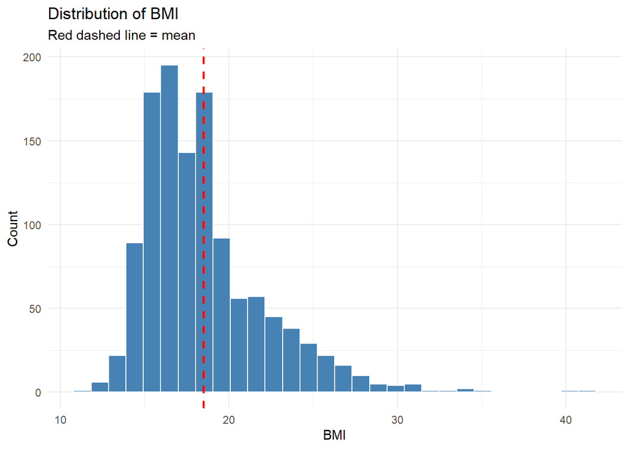

```r
#BMI
p1 <- ggplot(chs, aes(x = bmi)) +
  geom_histogram(bins = 30, fill = "steelblue", color = "white") +
  geom_vline(xintercept = mean(chs$bmi), color = "red",
             linetype = "dashed", linewidth = 0.8) +
  labs(title    = "Distribution of BMI",
       subtitle = "Red dashed line = mean",
       x = "BMI", y = "Count") +
  theme_minimal()
print(p1)
```

The BMI variable is right skewed with most of the values between 15 and 20. Majority of the sample are in the normal weight category with a small proportion being obese and overweight

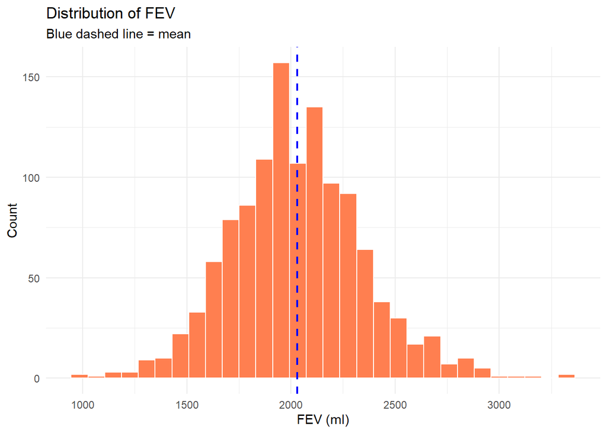

```r
# FEV
p2 <- ggplot(chs, aes(x = fev)) +
  geom_histogram(bins = 30, fill = "coral", color = "white") +
  geom_vline(xintercept = mean(chs$fev), color = "blue",
             linetype = "dashed", linewidth = 0.8) +
  labs(title    = "Distribution of FEV",
       subtitle = "Blue dashed line = mean",
       x = "FEV (ml)", y = "Count") +
  theme_minimal()
print(p2)
```

FEV is approximately normally distributed.

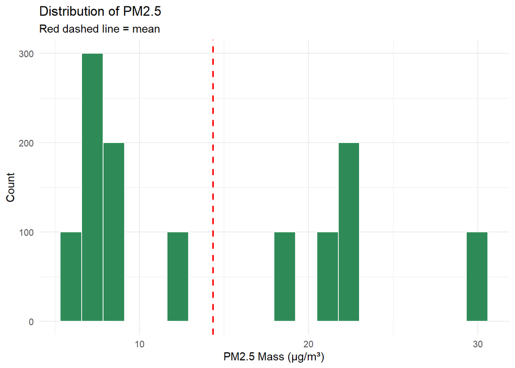

```r
# PM2.5
p3 <- ggplot(chs, aes(x = pm25_mass)) +
  geom_histogram(bins = 20, fill = "seagreen", color = "white") +
  geom_vline(xintercept = mean(chs$pm25_mass), color = "red",
             linetype = "dashed", linewidth = 0.8) +
  labs(title    = "Distribution of PM2.5",
       subtitle = "Red dashed line = mean",
       x = "PM2.5 Mass (µg/m³)", y = "Count") +
  theme_minimal()
print(p3)
```

PM2.5 seems to be right skewed and also abit clustered. Most participants had lower PM2.5 exposure but few also had higher exposure.

**Check for correlations between key variables**

```r
cor_check <- chs %>%
  select(bmi, fev, pm25_mass) %>%
  cor(use = "complete.obs")
print(round(cor_check, 3))
```

```
             bmi    fev pm25_mass
bmi        1.000  0.357    -0.039
fev        0.357  1.000    -0.073
pm25_mass -0.039 -0.073     1.000
```

BMI and FEV are moderately and positively correlated. PM2.5 shows a very weak negative association with FEV and BMI.

#### **Examine key associations**

**Question 1. Association betwen BMI and FEV**

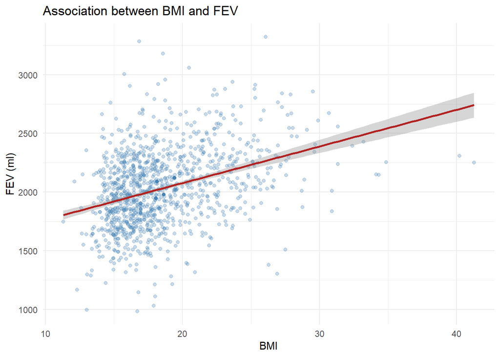

```r
ggplot(chs, aes(x = bmi, y = fev)) +
  geom_point(alpha = 0.3, color = "steelblue") +
  geom_smooth(method = "lm", color = "firebrick", se = TRUE) +
  labs(title = "Association between BMI and FEV",
       x = "BMI", y = "FEV (ml)") +
  theme_minimal()
```

```r
# Pearson correlation coefficient
cor_bmi_fev <- cor(chs$bmi, chs$fev, use = "complete.obs")
cat("Pearson correlation between BMI and FEV:", round(cor_bmi_fev, 3), "\n")
```

```
Pearson correlation between BMI and FEV: 0.357
```

There is a moderate positive association between BMI and FEV (r = 0.357). As BMI increases FEV also increases.

**Question 2. Association between smoke/gas exposure and FEV**

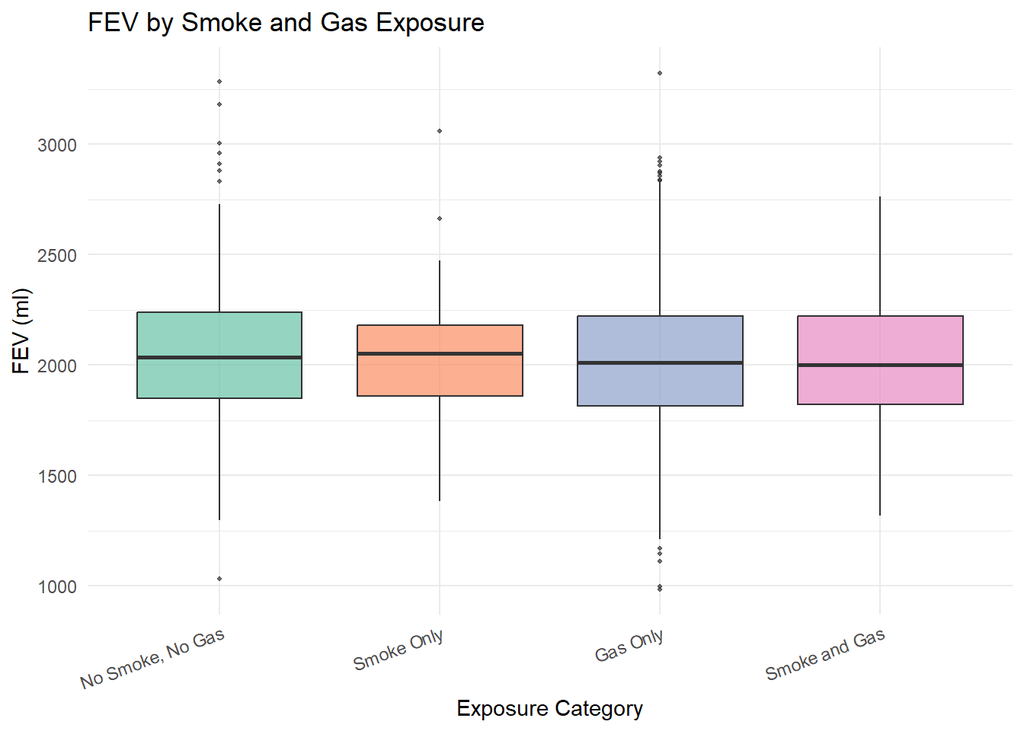

```r
ggplot(chs, aes(x = smoke_gas_exposure, y = fev, fill = smoke_gas_exposure)) +
  geom_boxplot(alpha = 0.7, outlier.size = 0.8) +
  scale_fill_brewer(palette = "Set2") +
  labs(title = "FEV by Smoke and Gas Exposure",
       x = "Exposure Category", y = "FEV (ml)",
       fill = "Exposure") +
  theme_minimal() +
  theme(axis.text.x    = element_text(angle = 20, hjust = 1),
        legend.position = "none")
```

```r
# Group means for reference
chs %>%
  group_by(smoke_gas_exposure) %>%
  summarise(Mean_FEV = round(mean(fev), 2),
            SD_FEV   = round(sd(fev), 2),
            N        = n())
```

```
# A tibble: 4 × 4
  smoke_gas_exposure Mean_FEV SD_FEV     N
  <fct>                 <dbl>  <dbl> <int>
1 No Smoke, No Gas      2057.   329.   219
2 Smoke Only            2056.   296.    36
3 Gas Only              2023.   319.   791
4 Smoke and Gas         2025.   301.   154
```

There is a very small difference in FEV across smoke/gas exposure categories. Exposure to gas or smoke does not appear to be strongly associated with FEV.

**Question 3. Association between PM2.5 and FEV**

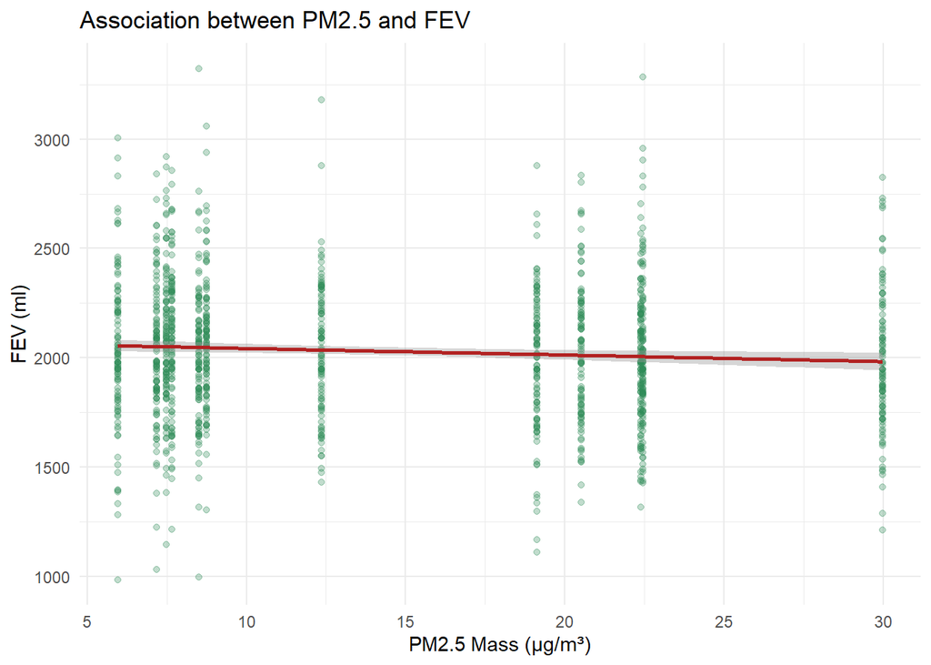

```r
ggplot(chs, aes(x = pm25_mass, y = fev)) +
  geom_point(alpha = 0.3, color = "seagreen") +
  geom_smooth(method = "lm", color = "firebrick", se = TRUE) +
  labs(title = "Association between PM2.5 and FEV",
       x = "PM2.5 Mass (µg/m³)", y = "FEV (ml)") +
  theme_minimal()
```

```r
# Pearson correlation coefficient
cor_pm25_fev <- cor(chs$pm25_mass, chs$fev, use = "complete.obs")
cat("Pearson correlation between PM2.5 and FEV:", round(cor_pm25_fev, 3), "\n")
```

```
Pearson correlation between PM2.5 and FEV: -0.073
```

The association between PM2.5 mass and FEV is weak and slightly negative (r = -0.073)

### Step 6: Visualizations

**Facet scatterplot: BMI vs FEV by Town**

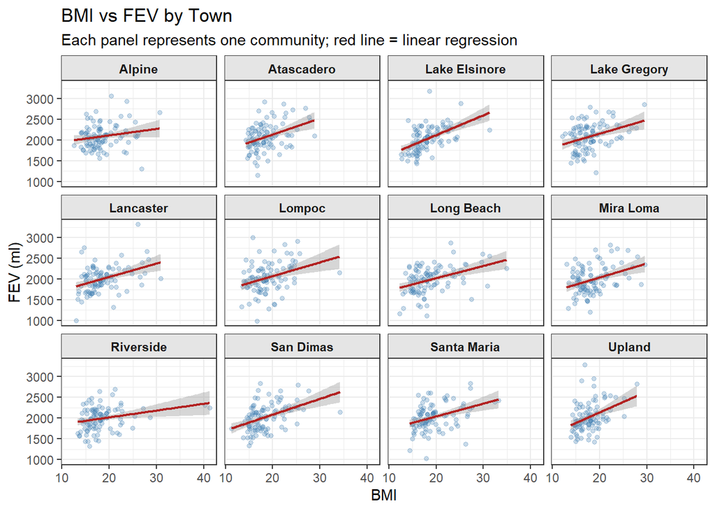

```r
ggplot(chs, aes(x = bmi, y = fev)) +
  geom_point(alpha = 0.3, color = "steelblue", size = 1.2) +
  geom_smooth(method = "lm", se = TRUE, color = "firebrick", linewidth = 0.8) +
  facet_wrap(~ location, ncol = 4) +
  labs(title    = "BMI vs FEV by Town",
       subtitle = "Each panel represents one community; red line = linear regression",
       x        = "BMI",
       y        = "FEV (ml)") +
  theme_bw(base_size = 11) +
  theme(strip.background = element_rect(fill = "gray90"),
        strip.text       = element_text(face = "bold"))
```

There is a positive association between BMI and FEV which is consistent across the towns.

**Stacked histograms of FEV by BMI category and FEV by smoke/gas exposure**

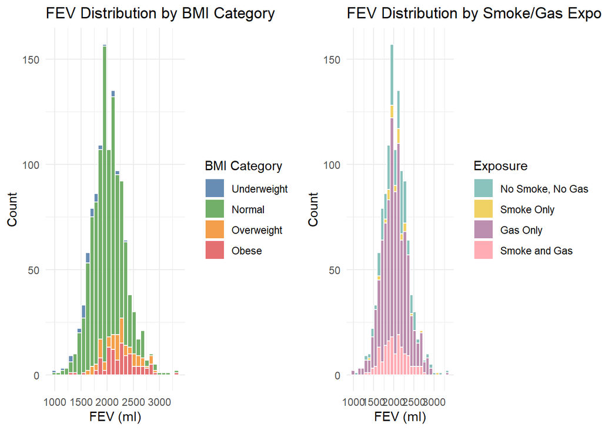

```r
bmi_colors <- c("Underweight" = "#4e79a7",
                "Normal"      = "#59a14f",
                "Overweight"  = "#f28e2b",
                "Obese"       = "#e15759")

smoke_colors <- c("No Smoke, No Gas" = "#76b7b2",
                  "Smoke Only"       = "#edc948",
                  "Gas Only"         = "#b07aa1",
                  "Smoke and Gas"    = "#ff9da7")

h1 <- ggplot(chs, aes(x = fev, fill = obesity_level)) +
  geom_histogram(bins = 30, position = "stack",
                 color = "white", alpha = 0.85) +
  scale_fill_manual(values = bmi_colors) +
  labs(title = "FEV Distribution by BMI Category",
       x = "FEV (ml)", y = "Count", fill = "BMI Category") +
  theme_minimal()

h2 <- ggplot(chs, aes(x = fev, fill = smoke_gas_exposure)) +
  geom_histogram(bins = 30, position = "stack",
                 color = "white", alpha = 0.85) +
  scale_fill_manual(values = smoke_colors) +
  labs(title = "FEV Distribution by Smoke/Gas Exposure",
       x = "FEV (ml)", y = "Count", fill = "Exposure") +
  theme_minimal()

grid.arrange(h1, h2, ncol = 2)
```

**FEV by BMI:** The stacked histogram shows that most children fall in the normal weight category and are spread across all FEV values. Obese and overweight children tend to have higher FEV values, while underweight children tend to have lower FEV values. This suggests a positive association between FEV and BMI.

**FEV by Smoke/gas exposure:** The FEV distributions are very similar across all four exposure groups, with all centered around 2000 ml. Gas only is the largest group and dominates the histogram. The smoke-only group has very few observations. There is no big difference in FEV between children with different smoke and gas exposures.

**Barchart of BMI by smoke/gas exposure**

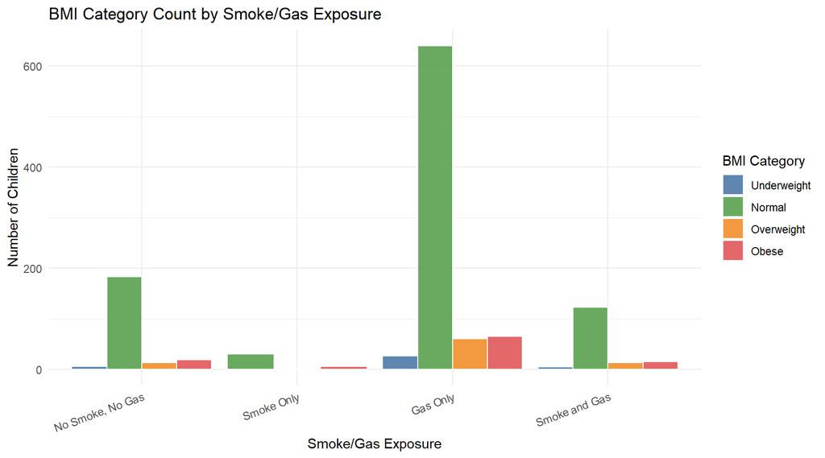

```r
ggplot(chs, aes(x = smoke_gas_exposure, fill = obesity_level)) +
  geom_bar(position = "dodge", color = "white", alpha = 0.9) +
  scale_fill_manual(values = bmi_colors) +
  labs(title = "BMI Category Count by Smoke/Gas Exposure",
       x     = "Smoke/Gas Exposure",
       y     = "Number of Children",
       fill  = "BMI Category") +
  theme_minimal() +
  theme(axis.text.x = element_text(angle = 20, hjust = 1))
```

Normal weight children are the most common BMI category across all four exposure groups. The gas only group has the largest number of children overall. The distribution of BMI categories looks similar across all exposure groups, suggesting that BMI and smoke/gas exposure are not related to each other.

**Statistical summary graphs of FEV by BMI and FEV by smoke/gas exposure**

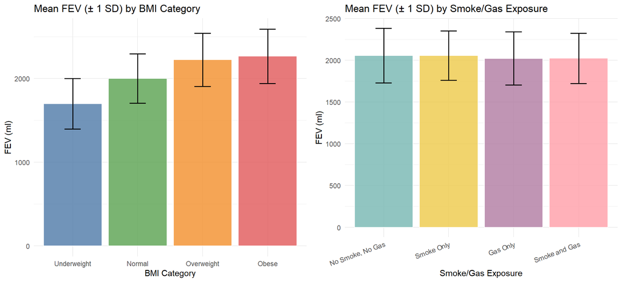

```r
s1 <- ggplot(chs, aes(x = obesity_level, y = fev, fill = obesity_level)) +
  stat_summary(fun = mean, geom = "bar", alpha = 0.8, color = "white") +
  stat_summary(fun.data = mean_sdl, fun.args = list(mult = 1),
               geom = "errorbar", width = 0.25, linewidth = 0.7) +
  scale_fill_manual(values = bmi_colors) +
  labs(title = "Mean FEV (± 1 SD) by BMI Category",
       x = "BMI Category", y = "FEV (ml)") +
  theme_minimal() +
  theme(legend.position = "none")

s2 <- ggplot(chs, aes(x = smoke_gas_exposure, y = fev,
                       fill = smoke_gas_exposure)) +
  stat_summary(fun = mean, geom = "bar", alpha = 0.8, color = "white") +
  stat_summary(fun.data = mean_sdl, fun.args = list(mult = 1),
               geom = "errorbar", width = 0.25, linewidth = 0.7) +
  scale_fill_manual(values = smoke_colors) +
  labs(title = "Mean FEV (± 1 SD) by Smoke/Gas Exposure",
       x = "Smoke/Gas Exposure", y = "FEV (ml)") +
  theme_minimal() +
  theme(axis.text.x    = element_text(angle = 20, hjust = 1),
        legend.position = "none")

grid.arrange(s1, s2, ncol = 2)
```

**BMI:** mean FEV increases steadily from underweight to obese, confirming a positive association between BMI and FEV.

**Smoke/gas exposure**: all four groups have nearly identical mean FEV values with heavily overlapping error bars, suggesting there is little to no association between smoke/gas exposure and FEV.

**A leaflet map with the PM 2.5 concentrations in each of the CHSS communities**

```r
town_map <- chs %>%
  select(location, pm25_mass, lat, lon) %>%
  distinct(location, .keep_all = TRUE)
pal <- colorNumeric(palette = "YlOrRd", domain = town_map$pm25_mass)

leaflet(town_map) %>%
  addTiles() %>%
  addCircleMarkers(
    lng          = ~lon,
    lat          = ~lat,
    radius       = ~pm25_mass / 2,
    color        = ~pal(pm25_mass),
    fillOpacity  = 0.8,
    stroke       = FALSE,
    label        = ~paste0(location, ": ", pm25_mass, " µg/m³"),
    labelOptions = labelOptions(noHide = FALSE)
  ) %>%
  addLabelOnlyMarkers(
    lng          = ~lon,
    lat          = ~lat,
    label        = ~paste0(location, " | ", pm25_mass, " µg/m³"),
    labelOptions = labelOptions(
      noHide    = TRUE,
      direction = "top",
      textOnly  = TRUE,
      style     = list(
        "font-size"   = "11px",
        "font-weight" = "bold",
        "color"       = "black"
      )
    )
  ) %>%
  addLegend(
    position = "bottomright",
    pal      = pal,
    values   = ~pm25_mass,
    title    = "PM2.5 (µg/m³)",
    opacity  = 0.8
  ) %>%
  addControl("<b>PM2.5 Concentrations Across CHS Communities</b>",
             position = "topright")
```

[interactive chart not shown]

**PM2.5 association with FEV**

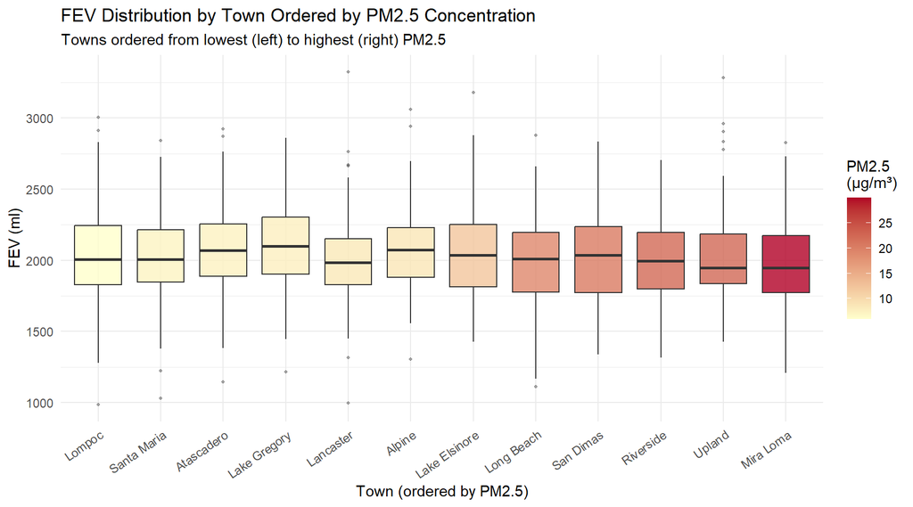

```r
# Order towns by PM2.5 level (low to high) to visualize the trend
town_order <- chs %>%
  select(location, pm25_mass) %>%
  distinct() %>%
  arrange(pm25_mass) %>%
  pull(location)

chs$location_ordered <- factor(chs$location, levels = town_order)

ggplot(chs, aes(x = location_ordered, y = fev, fill = pm25_mass)) +
  geom_boxplot(alpha = 0.8, outlier.size = 0.8, outlier.alpha = 0.4) +
  scale_fill_gradient(low = "#ffffcc", high = "#b10026",
                      name = "PM2.5\n(µg/m³)") +
  labs(title    = "FEV Distribution by Town Ordered by PM2.5 Concentration",
       subtitle = "Towns ordered from lowest (left) to highest (right) PM2.5",
       x        = "Town (ordered by PM2.5)",
       y        = "FEV (ml)") +
  theme_minimal() +
  theme(axis.text.x = element_text(angle = 35, hjust = 1))
```

When ordered from lowest to highest PM2.5 concentrations there seems to be a downward trend in median FEV. Towns with higher PM2.5 tend to have slighlty lower FEV values suggesting a weak negative association between PM2.5 and FEV. Though this trend was not consistent across all towns which means that other factors other than just air pollution could be influencing FEV in these regions.